# Working with Data - Assignment 1

### **Reflection**

5.1 An analysis of some of the most useful commands learnt in R has been carried out from Sept 11, 2017 to Nov 19, 2017. The commands used in the analysis are read, write, qplot and ggplot. Read and write commands are very useful and important commands to learn in R. Through read command one can load files to R and write command can be used to save the file to the system. qplot and ggplot commands are very useful for visual representation of data. qplot command is simpler than ggplot. However, ggplot can provide more functionality to our graphs.

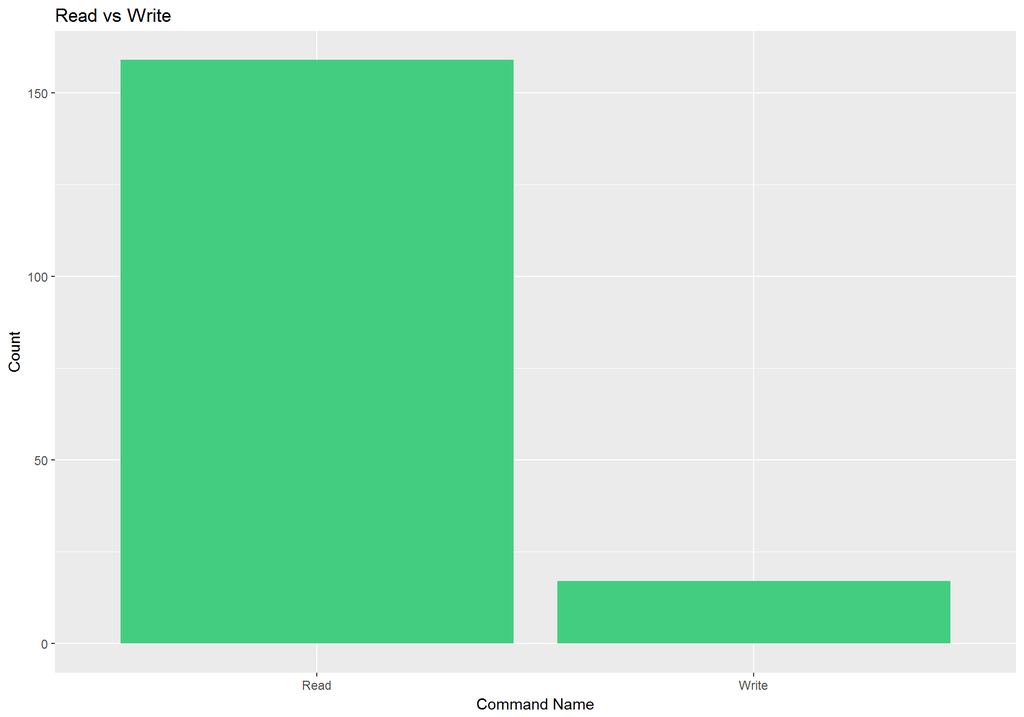

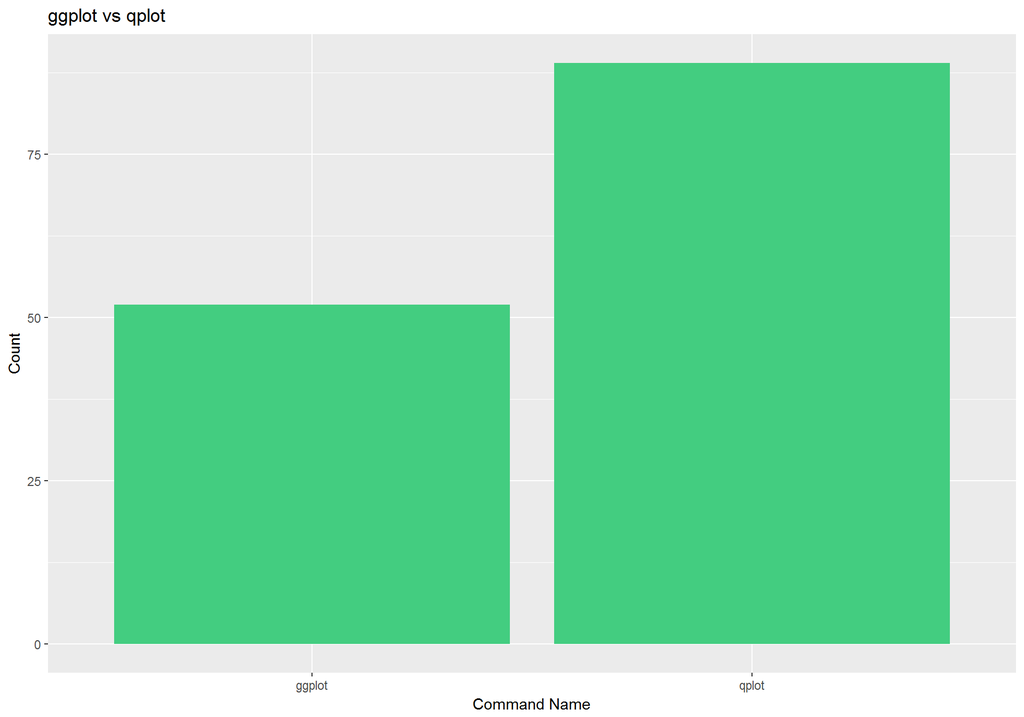

```
## Frequency of commands used over time
```

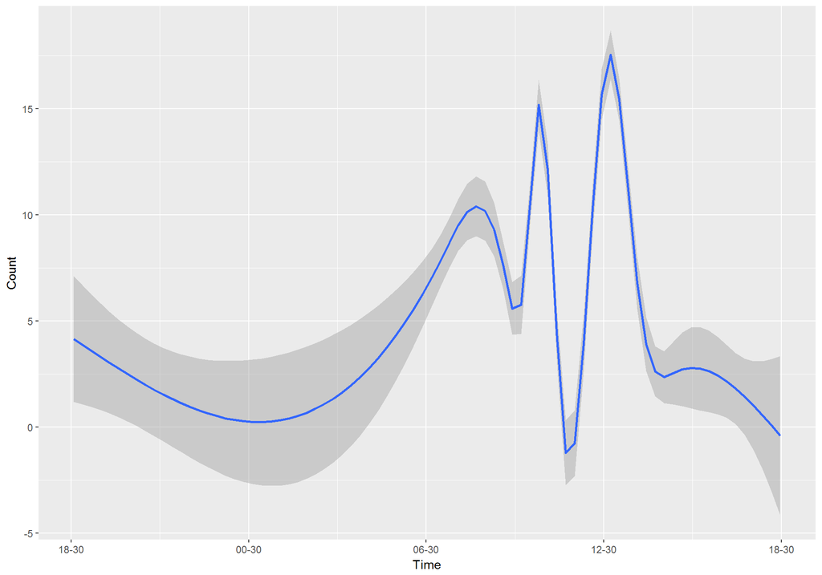

As evident from the graph ‘Read vs Write’, I have used read command more number of times than write. While working with R I need to load the data sets or files for which I need to use read command everytime. However, I have not been required to write many files to the system. From the graph ‘ggplot vs qplot’, it can be said that I have used qplot more than ggplot. I was introduced with qplot before ggplot. I find qplot simple and straight forward to use. However, while working on this assignment I learnt ggplot and understood the functionality it can bring to the visualisations. The last graph displays the frequency of commands over time. As can be seen I have worked more on R during morning till afternoon. As day proceeds towards evening my work with R reduces. I am most active with R at around 12.30pm.

5.2 Personal Reflections

I was introduced to R approx. two months back as a part of my Masters programme. However, I am impressed with how much I have learned in such little time. I would say prior knowledge of C++ helped me understand few areas of this language easily, however I stuggled with a few area as well.

1. Challenges overcome I have come across many challenging areas while working on the assignment. There were times when I knew the analysis I have to make or the result I am expecting, but finding the right set of commands to achieve that was a challenge. The work around I found was referring to the notes provided in class, seeking help from fellow classmates, and going through R manuals, and most of it worked for me.
2. Efficient work practices Efficient work practices can involve understanding the data and its nature properly and preparing questions prior to writing code and jumping to conclusions. Proper time management is also a key aspect to reaching the deadlines in time and without getting frustrated.Sticking to the universally accepted style of writing R code is also a good work practice.
3. Areas of frustration As mentioned in the first point, as I am not completely familiar with all the commands and funcions that can be used to perform a number of ideas or questions, hence it becomes frustrating at times when I am not even sure what I am searching for(functions or commands). Due to this reasons I had to drop a few very interesting yet very complex ideas.
4. Time management I must say I have so much to learn about efficient time management improve at it. However, during this assignment I tried to allot more time to R code as I realised I was taking more time to answer the questions through R code due to unfamiliarity with some of the areas of R. I gave less time to writing as compared to the time given to code, because I had clear idea of the analyses I had to perform and answers I had to answer.